# RWorkshop

Aug 2021

## Linear Regression

Estimate the regression coefficents in \[ \hat{testscr} = \hat{\beta_0} + \hat{\beta_1}str \] Where, \(testscr = (math + read)/2\) is the average test score in the district, and \(str = students/teachers\) is the student-teacher ratio.

- The data set `CASchools` is in the `AER` package.
1. Install the `AER` package.
2. Load the `CASchools` dataset.
3. Create new variables \(testscr\) and \(str\).
4. Estimate \(\hat\beta_0\) and \(\hat\beta_1\).

```r
library(AER)
data(CASchools, package = "AER")
caschool <- CASchools
caschool$str <- caschool$students/caschool$teachers
caschool$testscr <- (caschool$math + caschool$read)/2
```

```r
names(CASchools)
```

```
##  [1] "district"    "school"      "county"      "grades"      "students"
##  [6] "teachers"    "calworks"    "lunch"       "computer"    "expenditure"
## [11] "income"      "english"     "read"        "math"
```

```r
names(caschool)
```

```
##  [1] "district"    "school"      "county"      "grades"      "students"
##  [6] "teachers"    "calworks"    "lunch"       "computer"    "expenditure"
## [11] "income"      "english"     "read"        "math"        "str"
## [16] "testscr"
```

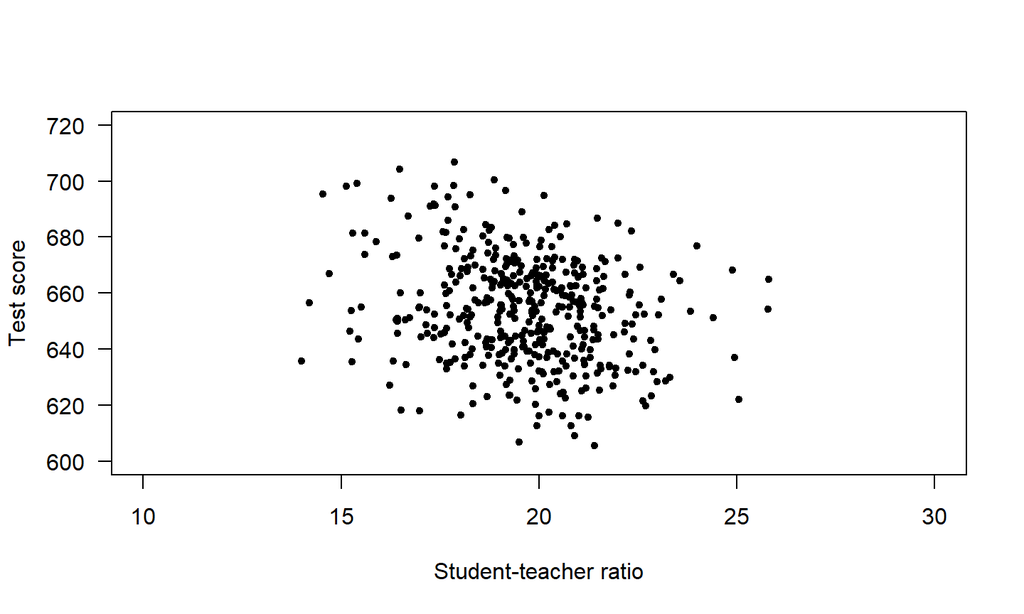

Scatterplot of TestScore vs Student-Teacher ratio (California School District Data

```r
plot(caschool$testscr ~ caschool$str,
     xlab = "Student-teacher ratio",
     ylab = "Test score", pch = 20, xlim = c(10,30),
     ylim = c(600, 720), las = 1)
```

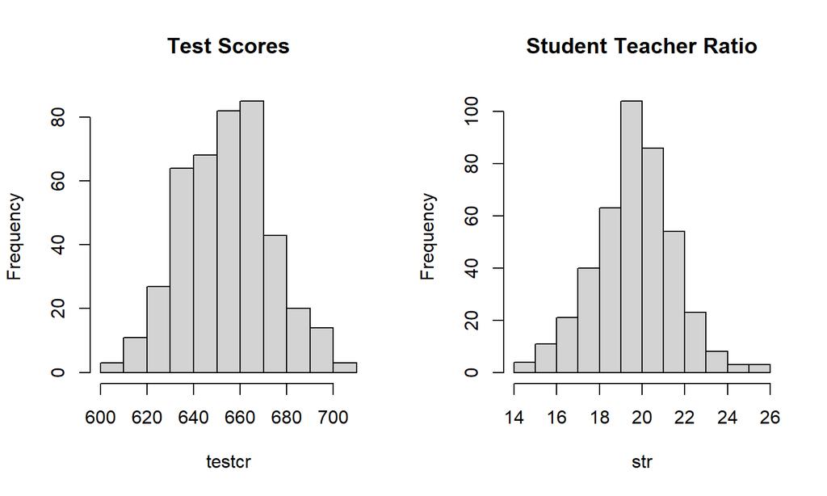

```r
par(mfrow = c(1,2))
hist(caschool$testscr, main = "Test Scores",
     xlab = "testcr", ylab = "Frequency")
hist(caschool$str, main = "Student Teacher Ratio",
     xlab = "str")
```

```r
summarytools::dfSummary(caschool[, c('testscr', 'str')], graph.col = FALSE)
```

```
## Data Frame Summary
## caschool
## Dimensions: 420 x 2
## Duplicates: 0
##
## ---------------------------------------------------------------------------------------
## No   Variable    Stats / Values              Freqs (% of Valid)    Valid      Missing
## ---- ----------- --------------------------- --------------------- ---------- ---------
## 1    testscr     Mean (sd) : 654.2 (19.1)    389 distinct values   420        0
##      [numeric]   min < med < max:                                  (100.0%)   (0.0%)
##                  605.6 < 654.4 < 706.8
##                  IQR (CV) : 26.6 (0)
##
## 2    str         Mean (sd) : 19.6 (1.9)      413 distinct values   420        0
##      [numeric]   min < med < max:                                  (100.0%)   (0.0%)
##                  14 < 19.7 < 25.8
##                  IQR (CV) : 2.3 (0.1)
## ---------------------------------------------------------------------------------------
```

```r
# summary() can also be used.
```

- The `lm()` function is used to fit a **L**inear **M**odel.
- Usage

```r
lm(formula, data, subset)
```

- The California Schools model

```r
# fit a linear model and save it to an `lm` object
lm_model1 <- lm(formula = testscr ~ str, data = caschool)
class(lm_model1)
```

```
## [1] "lm"
```

You can directly print the `lm_model1` output

```r
lm_model1
```

```
##
## Call:
## lm(formula = testscr ~ str, data = caschool)
##
## Coefficients:
## (Intercept)          str
##      698.93        -2.28
```

Or, you can also print the `summary()`.

```r
summary(lm_model1)
```

```
##
## Call:
## lm(formula = testscr ~ str, data = caschool)
##
## Residuals:
##     Min      1Q  Median      3Q     Max
## -47.727 -14.251   0.483  12.822  48.540
##
## Coefficients:
##             Estimate Std. Error t value Pr(>|t|)
## (Intercept) 698.9329     9.4675  73.825  < 2e-16 ***
## str          -2.2798     0.4798  -4.751 2.78e-06 ***
## ---
## Signif. codes:  0 '***' 0.001 '**' 0.01 '*' 0.05 '.' 0.1 ' ' 1
##
## Residual standard error: 18.58 on 418 degrees of freedom
## Multiple R-squared:  0.05124,    Adjusted R-squared:  0.04897
## F-statistic: 22.58 on 1 and 418 DF,  p-value: 2.783e-06
```

- Add a regression line.
- First, we shall extract the coefficients from `lm_model1`

```r
b1 <- coef(lm_model1)[[1]]
b2 <- abs(coef(lm_model1)[[2]])
```

- We shall also need `expr()` from `rlang` package to add Mathematical Annotation in R.

```r
library(rlang)
```

- Use `?plotmath()` and `demo(plotmath)` for usage.

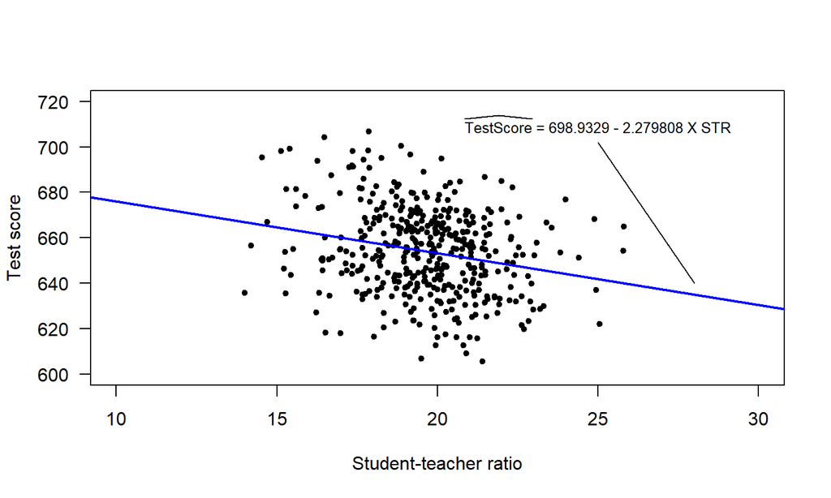

```r
plot(caschool$testscr ~ caschool$str,
     xlab = "Student-teacher ratio",
     ylab = "Test score", pch = 20, xlim = c(10,30),
     ylim = c(600, 720), las = 1)

# add the model fit
abline(lm_model1, col = "blue", lwd = 2)
text(25, 710, expr(paste(widehat(TestScore)~"="~ !!b1~"-"~ !!b2~X~STR)), cex = 0.8)
arrows(25,702, 28,640, length = 0)
```

## The omitted variable(s)

- What was our previous assessment about `testscr`?
  - We estimated the linear model \(\hat{testscr} = 698.9-2.27\times str\)
  - Interpretation: Class with higher `str` i.e. larger class size tend to have lower `testscr`.
- Reasons for considering `english` as omitted variable;
  - Large immigration population in California
  - Students in the district who are still learning English.
  - Students who are still learning English might perform worse on standardized tests as compared to native English speakers.
  - The larger class sizes `str` might also have students still learning English. Therefore, considering the OLS estimate \(\hat{testscr} = 698.9-2.27\times str\), the policy would be considering lowering the `str` value to improve `testscr`. But this might not solve the problem because of the English learning students in the class.
- Our multiple regression model is \[ \hat{testscr} = \beta_0 + \beta_1str + \beta_2english \] where \(english\) is the percentage of students in the district who are English learners.

```r
# summary stats for the three variables
summary(caschool[c("testscr", "str", "english")])
```

```
##     testscr           str           english
##  Min.   :605.5   Min.   :14.00   Min.   : 0.000
##  1st Qu.:640.0   1st Qu.:18.58   1st Qu.: 1.941
##  Median :654.5   Median :19.72   Median : 8.778
##  Mean   :654.2   Mean   :19.64   Mean   :15.768
##  3rd Qu.:666.7   3rd Qu.:20.87   3rd Qu.:22.970
##  Max.   :706.8   Max.   :25.80   Max.   :85.540
```

```r
summarytools::descr(caschool[c("testscr", "str", "english")])
```

```
## Descriptive Statistics
## caschool
## N: 420
##
##                     english      str   testscr
## ----------------- --------- -------- ---------
##              Mean     15.77    19.64    654.16
##           Std.Dev     18.29     1.89     19.05
##               Min      0.00    14.00    605.55
##                Q1      1.94    18.58    640.00
##            Median      8.78    19.72    654.45
##                Q3     23.00    20.87    666.67
##               Max     85.54    25.80    706.75
##               MAD     11.76     1.70     19.39
##               IQR     21.03     2.29     26.61
##                CV      1.16     0.10      0.03
##          Skewness      1.42    -0.03      0.09
##       SE.Skewness      0.12     0.12      0.12
##          Kurtosis      1.41     0.59     -0.27
##           N.Valid    420.00   420.00    420.00
##         Pct.Valid    100.00   100.00    100.00
```

```r
summarytools::dfSummary(caschool, graph.col = FALSE)
```

```
## Data Frame Summary
## caschool
## Dimensions: 420 x 16
## Duplicates: 0
##
## -----------------------------------------------------------------------------------------------
## No   Variable       Stats / Values                   Freqs (% of Valid)    Valid      Missing
## ---- -------------- -------------------------------- --------------------- ---------- ---------
## 1    district       1. 61382                           1 ( 0.2%)           420        0
##      [character]    2. 61457                           1 ( 0.2%)           (100.0%)   (0.0%)
##                     3. 61499                           1 ( 0.2%)
##                     4. 61507                           1 ( 0.2%)
##                     5. 61523                           1 ( 0.2%)
##                     6. 61549                           1 ( 0.2%)
##                     7. 61572                           1 ( 0.2%)
##                     8. 61655                           1 ( 0.2%)
##                     9. 61705                           1 ( 0.2%)
##                     10. 61713                          1 ( 0.2%)
##                     [ 410 others ]                   410 (97.6%)
##
## 2    school         1. Lakeside Union Elementary       3 ( 0.7%)           420        0
##      [character]    2. Mountain View Elementary        3 ( 0.7%)           (100.0%)   (0.0%)
##                     3. Jefferson Elementary            2 ( 0.5%)
##                     4. Liberty Elementary              2 ( 0.5%)
##                     5. Ocean View Elementary           2 ( 0.5%)
##                     6. Pacific Union Elementary        2 ( 0.5%)
##                     7. Pioneer Union Elementary        2 ( 0.5%)
##                     8. Pleasant Valley Elementar       2 ( 0.5%)
##                     9. South Bay Union Elementar       2 ( 0.5%)
##                     10. Ackerman Elementary            1 ( 0.2%)
##                     [ 399 others ]                   399 (95.0%)
##
## 3    county         1. Alameda                         1 ( 0.2%)           420        0
##      [factor]       2. Butte                           6 ( 1.4%)           (100.0%)   (0.0%)
##                     3. Calaveras                       1 ( 0.2%)
##                     4. Contra Costa                    7 ( 1.7%)
##                     5. El Dorado                      10 ( 2.4%)
##                     6. Fresno                         12 ( 2.9%)
##                     7. Glenn                           3 ( 0.7%)
##                     8. Humboldt                       17 ( 4.0%)
```

[output cut: 52 more lines]

```
## 14   math           Mean (sd) : 653.3 (18.8)         324 distinct values   420        0
##      [numeric]      min < med < max:                                       (100.0%)   (0.0%)
##                     605.4 < 652.4 < 709.5
##                     IQR (CV) : 26.5 (0)
##
## 15   str            Mean (sd) : 19.6 (1.9)           413 distinct values   420        0
##      [numeric]      min < med < max:                                       (100.0%)   (0.0%)
##                     14 < 19.7 < 25.8
##                     IQR (CV) : 2.3 (0.1)
##
## 16   testscr        Mean (sd) : 654.2 (19.1)         389 distinct values   420        0
##      [numeric]      min < med < max:                                       (100.0%)   (0.0%)
##                     605.6 < 654.4 < 706.8
##                     IQR (CV) : 26.6 (0)
## -----------------------------------------------------------------------------------------------
```

**Estimated model**

```r
lm_multi <- lm(testscr ~ str + english, data = caschool)
summary(lm_multi)
```

```
##
## Call:
## lm(formula = testscr ~ str + english, data = caschool)
##
## Residuals:
##     Min      1Q  Median      3Q     Max
## -48.845 -10.240  -0.308   9.815  43.461
##
## Coefficients:
##              Estimate Std. Error t value Pr(>|t|)
## (Intercept) 686.03224    7.41131  92.566  < 2e-16 ***
## str          -1.10130    0.38028  -2.896  0.00398 **
## english      -0.64978    0.03934 -16.516  < 2e-16 ***
## ---
## Signif. codes:  0 '***' 0.001 '**' 0.01 '*' 0.05 '.' 0.1 ' ' 1
##
## Residual standard error: 14.46 on 417 degrees of freedom
## Multiple R-squared:  0.4264, Adjusted R-squared:  0.4237
## F-statistic:   155 on 2 and 417 DF,  p-value: < 2.2e-16
```

## Regression when \(X\) is a binary variable

- **Equation with a binary regressor**: \[Y_i = \beta_0 + \beta_1 D_i + u_i\] \[D_i = \begin{cases} 1 \ \ \text{if $STR$ in $i^{th}$ school district < 20} \\ 0 \ \ \text{if $STR$ in $i^{th}$ school district $\geq$ 20} \\ \end{cases}\]
- Our regression model is \[ testscr_i = \beta_0 + \beta_1 D_i + u_i. \]

**What is the difference in the expected test scores in districts with lower student-teacher ratio \(STR < 20 (D_i = 1)\) and those with higher student-teacher ratio \(STR \geq 20 (D_i=0)\)?**

- Create the dummy variable and append it to the dataset.

```r
# create D and append
caschool$D <- as.factor(ifelse(caschool$str < 20, 1, 0))

# check the dataset
str(caschool)
```

```
## 'data.frame':    420 obs. of  17 variables:
##  $ district   : chr  "75119" "61499" "61549" "61457" ...
##  $ school     : chr  "Sunol Glen Unified" "Manzanita Elementary" "Thermalito Union Elementary" "Golden Feather Union Elementary" ...
##  $ county     : Factor w/ 45 levels "Alameda","Butte",..: 1 2 2 2 2 6 29 11 6 25 ...
##  $ grades     : Factor w/ 2 levels "KK-06","KK-08": 2 2 2 2 2 2 2 2 2 1 ...
##  $ students   : num  195 240 1550 243 1335 ...
##  $ teachers   : num  10.9 11.1 82.9 14 71.5 ...
##  $ calworks   : num  0.51 15.42 55.03 36.48 33.11 ...
##  $ lunch      : num  2.04 47.92 76.32 77.05 78.43 ...
##  $ computer   : num  67 101 169 85 171 25 28 66 35 0 ...
##  $ expenditure: num  6385 5099 5502 7102 5236 ...
##  $ income     : num  22.69 9.82 8.98 8.98 9.08 ...
##  $ english    : num  0 4.58 30 0 13.86 ...
##  $ read       : num  692 660 636 652 642 ...
##  $ math       : num  690 662 651 644 640 ...
##  $ str        : num  17.9 21.5 18.7 17.4 18.7 ...
##  $ testscr    : num  691 661 644 648 641 ...
##  $ D          : Factor w/ 2 levels "0","1": 2 1 2 2 2 1 2 1 2 1 ...
```

- Plot the data

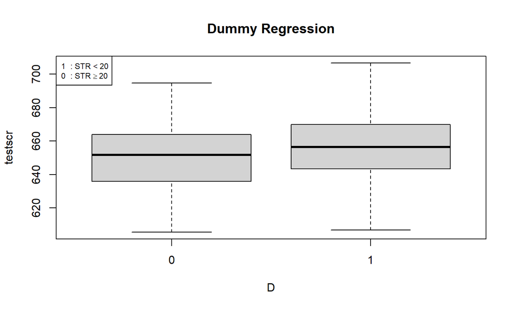

```r
plot(testscr ~ D, data = caschool, main = "Dummy Regression")
legend("topleft", legend = c(": STR < 20", expression(paste(": ",STR >= 20))),
       pch = c("1", "0"), cex = 0.7)
```

**Estimate the dummy regression model**

```r
lm_dummy <- lm(testscr ~ D, data = caschool)
summary(lm_dummy)
```

```
##
## Call:
## lm(formula = testscr ~ D, data = caschool)
##
## Residuals:
##     Min      1Q  Median      3Q     Max
## -50.496 -14.029  -0.346  12.884  49.504
##
## Coefficients:
##             Estimate Std. Error t value Pr(>|t|)
## (Intercept)  650.077      1.393 466.666  < 2e-16 ***
## D1             7.169      1.847   3.882  0.00012 ***
## ---
## Signif. codes:  0 '***' 0.001 '**' 0.01 '*' 0.05 '.' 0.1 ' ' 1
##
## Residual standard error: 18.74 on 418 degrees of freedom
## Multiple R-squared:  0.0348, Adjusted R-squared:  0.0325
## F-statistic: 15.07 on 1 and 418 DF,  p-value: 0.0001202
```

**The interpretation of the coefficients in this regression model is as follows:**

\(\beta_0\) = 650.08 is the expected test score in districts where \(STR \geq 20\).

\(\beta_1\) = 7.17 is the difference in the expected test score between districts with \(STR < 20\) and those with \(STR \geq 20\).

**Observation:**

One can see that the expected test score in districts with STR<20 (\(D_i=1\)) is predicted to be 650.1+7.17=657.27 while districts with STR≥20 (\(D_i=0\)) are expected to have an average test score of only 650.1.

## Multiple models in `stargazer` with heteroskedasticity-robust standard errors.

We shall consider the following models and graphically inspect the correlation and summarise all the regression results in a table. \[ \begin{align*} \text{(I) }\text{testscr} &= \beta_0 + \beta_1\text{str} + u\\ \text{(II) }\text{testscr} &= \beta_0 + \beta_1\text{str} + \beta_2\text{english} + u\\ \text{(III) }\text{testscr} &= \beta_0 + \beta_1\text{str} + \beta_2\text{english} + \beta_3\text{lunch} + u\\ \text{(IV) }\text{testscr} &= \beta_0 + \beta_1\text{str} + \beta_2\text{english} + \beta_3\text{calworks} + u\\ \text{(V) }\text{testscr} &= \beta_0 + \beta_1\text{str} + \beta_2\text{english} + \beta_3\text{lunch} + \beta_4\text{calworks} + u\\ \end{align*} \]

where, `testscr`- test score `str` - student-teacher ratio `english` - percentage of english learners `lunch` - percentage of students that qualify for a free or subsidised lunch due to family incomes below a certain threshold. `calworks` - percentage of students qualifying for the *calworks* income assistance programme.

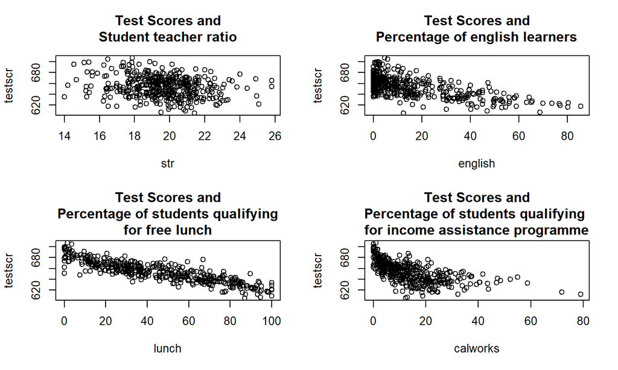

```r
par(mfrow = c(2,2))
plot(testscr ~ str, data = caschool, main = "Test Scores and\nStudent teacher ratio")

plot(testscr ~ english, data = caschool, main = "Test Scores and\nPercentage of english learners")

plot(testscr ~ lunch, data = caschool, main = "Test Scores and\nPercentage of students qualifying\nfor free lunch")

plot(testscr ~ calworks, data = caschool, main = "Test Scores and\nPercentage of students qualifying \nfor income assistance programme")
```

```r
# models
I <- lm(testscr ~ str, data = caschool)
II <- lm(testscr ~ str + english, data = caschool)
III <- lm(testscr ~ str + english + lunch, data = caschool)
IV <- lm(testscr ~ str + english + calworks, data = caschool)
V <- lm(testscr ~ str + english + lunch + calworks, data = caschool)

# gather all the robust standard error values in a list
robust_se <- list(
  sqrt(diag(sandwich::vcovHC(I, type = "HC1"))),
  sqrt(diag(sandwich::vcovHC(II, type = "HC1"))),
  sqrt(diag(sandwich::vcovHC(III, type = "HC1"))),
  sqrt(diag(sandwich::vcovHC(IV, type = "HC1"))),
  sqrt(diag(sandwich::vcovHC(V, type = "HC1")))
)

## use the `stargazer()` function to represent the output in a tabular form
stargazer::stargazer(I, II, III, IV, V, type = "text",
                     title = "Analysis of caschool dataset.",
                     se = robust_se, digits = 3,
                     column.labels = c("I", "II", "III", "IV", "V"),
                     column.sep.width = "1pt",
                     notes = "Heteroskedasticity robust standard errors are given in parentheses under coefficients.",
                     notes.append = TRUE)
```

```
##
## Analysis of caschool dataset.
## ===============================================================================================================================================
##                                                                         Dependent variable:
##                     ---------------------------------------------------------------------------------------------------------------------------
##                                                                               testscr
##                                I                       II                      III                       IV                       V
##                               (1)                     (2)                      (3)                      (4)                      (5)
## -----------------------------------------------------------------------------------------------------------------------------------------------
## str                        -2.280***                -1.101**                -0.998***                -1.308***                -1.014***
##                             (0.519)                 (0.433)                  (0.270)                  (0.339)                  (0.269)
##
## english                                            -0.650***                -0.122***                -0.488***                -0.130***
##                                                     (0.031)                  (0.033)                  (0.030)                  (0.036)
##
## lunch                                                                       -0.547***                                         -0.529***
##                                                                              (0.024)                                           (0.038)
##
## calworks                                                                                             -0.790***                  -0.048
##                                                                                                       (0.068)                  (0.059)
##
## Constant                  698.933***               686.032***               700.150***               697.999***               700.392***
##                            (10.364)                 (8.728)                  (5.568)                  (6.920)                  (5.537)
##
## -----------------------------------------------------------------------------------------------------------------------------------------------
## Observations                  420                     420                      420                      420                      420
## R2                           0.051                   0.426                    0.775                    0.629                    0.775
## Adjusted R2                  0.049                   0.424                    0.773                    0.626                    0.773
## Residual Std. Error    18.581 (df = 418)       14.464 (df = 417)         9.080 (df = 416)        11.654 (df = 416)         9.084 (df = 415)
## F Statistic         22.575*** (df = 1; 418) 155.014*** (df = 2; 417) 476.306*** (df = 3; 416) 234.638*** (df = 3; 416) 357.054*** (df = 4; 415)
## ===============================================================================================================================================
## Note:                                                                                                               *p<0.1; **p<0.05; ***p<0.01
##                                                          Heteroskedasticity robust standard errors are given in parentheses under coefficients.
```